# Homework_1

Nicole_Kerrison

9/12/2020

Question 1

The names of the people in my homework group are Isabela Vieira, Akimawe Kadiri, Christopher Tinevra, Mostafa Ragheb. We are meeting weekly on zoom calls to discuss the homework and the class notes.

Question 3 - A fair Dice Roll

Theoretical probability of rolling a 6 - the expectation is to roll a 6 at least once 1/36 (.02778)

How to create a fair dice simulation in R. First we begin by creating a variable called dice rolls and set the size to 2 so we make clear we are using 2 dice and any time we roll we want replacements of numbers.

```r
die.rolls <- function (){
  dice <- sample(x=1:6, size = 2, replace = TRUE)}
```

Then we want to create a simulation that runs this 20 times

```r
simtrial <- replicate(20,die.rolls())
```

Run the trial

```r
simtrial
```

```
##      [,1] [,2] [,3] [,4] [,5] [,6] [,7] [,8] [,9] [,10] [,11] [,12] [,13] [,14]
## [1,]    4    6    6    5    2    5    2    3    1     5     2     6     2     5
## [2,]    4    4    3    1    3    4    4    4    4     5     4     1     6     6
##      [,15] [,16] [,17] [,18] [,19] [,20]
## [1,]     5     6     4     2     1     2
## [2,]     4     4     6     6     2     5
```

Then create a table to of the simulation once its complete.

```r
table(simtrial)
```

```
## simtrial
##  1  2  3  4  5  6
##  4  7  3 11  7  8
```

#Then generate the frequency of the outcome and plot the data

Frequency - this is the % of times we virtually rolled the numbers below

```r
table(simtrial)/length(simtrial)
```

```
## simtrial
##     1     2     3     4     5     6
## 0.100 0.175 0.075 0.275 0.175 0.200
```

Plot - This plots the number of times in the simulation roll that we record a number

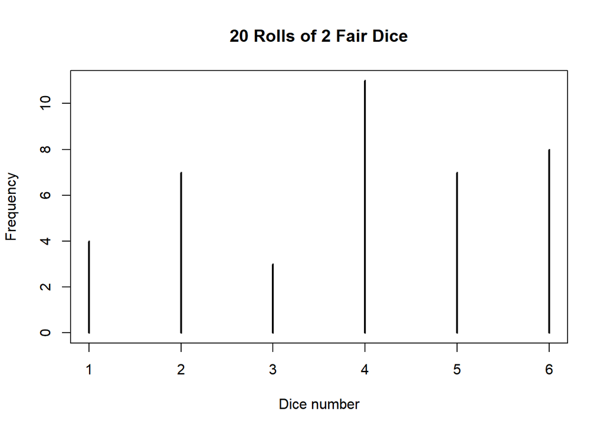

```r
plot(table(simtrial), xlab = 'Dice number', ylab = 'Frequency', main = '20 Rolls of 2 Fair Dice')
```

Question 4

Lecture 1 Introduction

```r
x <- 1:50
w <- 1 + sqrt(x)/2
example1 <- data.frame(x=x, y= x + rnorm(x)*w)
attach(example1)
fm <- lm(y ~ x)
summary(fm)
```

```
##
## Call:
## lm(formula = y ~ x)
##
## Residuals:
##     Min      1Q  Median      3Q     Max
## -6.7303 -1.7733 -0.0702  2.2120  6.2244
##
## Coefficients:
##             Estimate Std. Error t value Pr(>|t|)
## (Intercept) -0.06586    0.89322  -0.074    0.942
## x            1.02103    0.03049  33.492   <2e-16 ***
## ---
## Signif. codes:  0 '***' 0.001 '**' 0.01 '*' 0.05 '.' 0.1 ' ' 1
##
## Residual standard error: 3.111 on 48 degrees of freedom
## Multiple R-squared:  0.959,  Adjusted R-squared:  0.9581
## F-statistic:  1122 on 1 and 48 DF,  p-value: < 2.2e-16
```

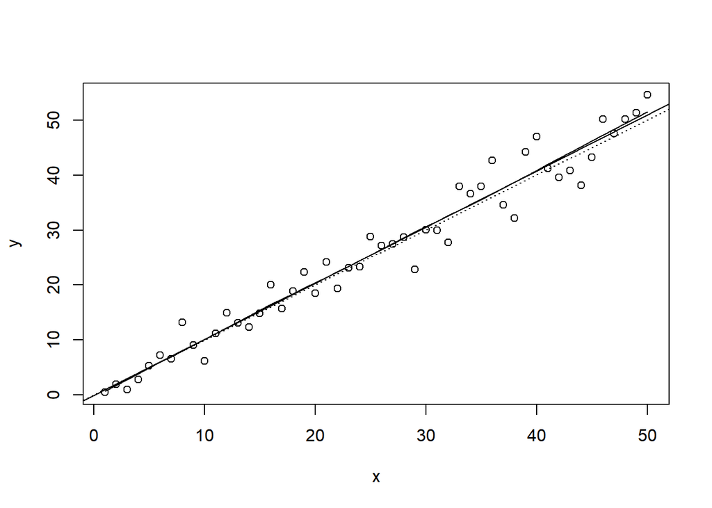

```r
lrf <- lowess(x, y)
plot(x, y)
lines(x, lrf$y)
abline(0, 1, lty=3)
abline(coef(fm))
```

```r
detach()
```

```r
setwd("C:\\Users\\Nicol\\Documents\\CCNY\\Graduate School\\Fall 2020\\Econometrics\\ACS Data for R")
load("acs2017_ny_data.RData")
acs2017_ny[1:10,1:7]
```

```
##    AGE female educ_nohs educ_hs educ_somecoll educ_college educ_advdeg
## 1   72      1         0       0             0            0           1
## 2   72      0         0       0             0            0           1
## 3   31      0         0       0             0            1           0
## 4   28      1         0       0             0            1           0
## 5   54      0         0       0             0            0           1
## 6   45      1         0       1             0            0           0
## 7   84      1         0       0             1            0           0
## 8   71      0         0       0             0            1           0
## 9   68      1         0       0             1            0           0
## 10  37      1         1       0             0            0           0
```

```r
attach(acs2017_ny)
```

```r
summary(acs2017_ny)
```

```
##       AGE            female         educ_nohs        educ_hs
##  Min.   : 0.00   Min.   :0.0000   Min.   :0.000   Min.   :0.0000
##  1st Qu.:22.00   1st Qu.:0.0000   1st Qu.:0.000   1st Qu.:0.0000
##  Median :42.00   Median :1.0000   Median :0.000   Median :0.0000
##  Mean   :41.57   Mean   :0.5156   Mean   :0.271   Mean   :0.2804
##  3rd Qu.:60.00   3rd Qu.:1.0000   3rd Qu.:1.000   3rd Qu.:1.0000
##  Max.   :95.00   Max.   :1.0000   Max.   :1.000   Max.   :1.0000
##
##  educ_somecoll    educ_college     educ_advdeg                  SCHOOL
##  Min.   :0.000   Min.   :0.0000   Min.   :0.000   N/A              :  5569
##  1st Qu.:0.000   1st Qu.:0.0000   1st Qu.:0.000   No, not in school:144968
##  Median :0.000   Median :0.0000   Median :0.000   Yes, in school   : 46048
##  Mean   :0.173   Mean   :0.1567   Mean   :0.119   Missing          :     0
##  3rd Qu.:0.000   3rd Qu.:0.0000   3rd Qu.:0.000
##  Max.   :1.000   Max.   :1.0000   Max.   :1.000
##
##                         EDUC
##  Grade 12                 :55119
##  4 years of college       :30802
##  5+ years of college      :23385
##  1 year of college        :19947
##  Nursery school to grade 4:14240
##  2 years of college       :14065
##  (Other)                  :39027
##                                           EDUCD
##  Regular high school diploma                 :35689
##  Bachelor's degree                           :30802
##  1 or more years of college credit, no degree:19947
##  Master's degree                             :17010
##  Associate's degree, type not specified      :14065
##  Some college, but less than 1 year          : 9086
##  (Other)                                     :69986
##                                      DEGFIELD
##  N/A                                     :142398
##  Business                                :  9802
##  Education Administration and Teaching   :  6708
##  Social Sciences                         :  4836
##  Medical and Health Sciences and Services:  3919
##  Fine Arts                               :  3491
##  (Other)                                 : 25431
```

[output cut: 209 more lines]

```
##  Min.   :0.00000   Min.   :0.00000   Min.   :0.000     Min.   :0.0000
##  1st Qu.:0.00000   1st Qu.:0.00000   1st Qu.:0.000     1st Qu.:0.0000
##  Median :0.00000   Median :0.00000   Median :0.000     Median :0.0000
##  Mean   :0.01332   Mean   :0.05506   Mean   :0.122     Mean   :0.1965
##  3rd Qu.:0.00000   3rd Qu.:0.00000   3rd Qu.:0.000     3rd Qu.:0.0000
##  Max.   :1.00000   Max.   :1.00000   Max.   :1.000     Max.   :1.0000
##
##  below_200poverty   foodstamps
##  Min.   :0.0000   Min.   :0.0000
##  1st Qu.:0.0000   1st Qu.:0.0000
##  Median :0.0000   Median :0.0000
##  Mean   :0.2676   Mean   :0.1465
##  3rd Qu.:1.0000   3rd Qu.:0.0000
##  Max.   :1.0000   Max.   :1.0000
##
```

```r
print(NN_obs <- length(AGE))
```

```
## [1] 196585
```

```r
summary(AGE[female == 1])
```

```
##    Min. 1st Qu.  Median    Mean 3rd Qu.    Max.
##    0.00   23.00   44.00   42.72   61.00   95.00
```

```r
summary(AGE[!female])
```

```
##    Min. 1st Qu.  Median    Mean 3rd Qu.    Max.
##    0.00   21.00   40.00   40.35   59.00   95.00
```

```r
mean(AGE[female == 1])
```

```
## [1] 42.71629
```

```r
sd(AGE[female == 1])
```

```
## [1] 23.72012
```

```r
mean(AGE[!female])
```

```
## [1] 40.35398
```

```r
sd(AGE[!female])
```

```
## [1] 23.1098
```

Sample data to look at

```r
summary(INCWAGE[DEGFIELD])
```

```
##    Min. 1st Qu.  Median    Mean 3rd Qu.    Max.    NA's
##       0  160000  160000  142799  160000  638000    8083
```

Histogram of the data (and the issues with Topcoding)

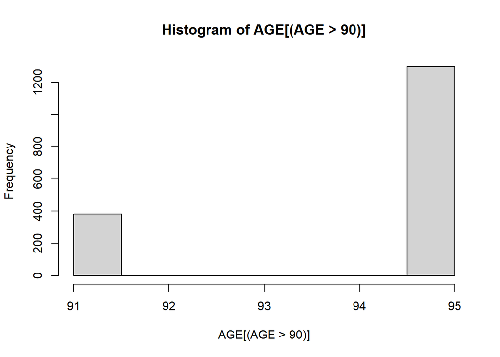

```r
hist(AGE[(AGE > 90)])
```

```r
mean(AGE[ (female ==1) & (AGE<90) ])
```

```
## [1] 41.98866
```

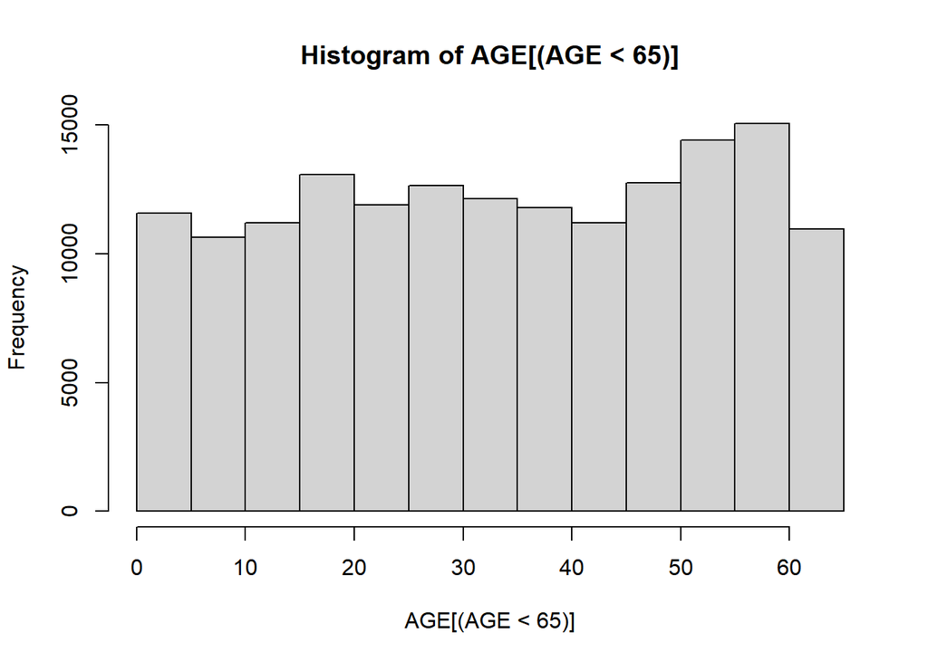

```r
hist(AGE[(AGE < 65)])
```

Question 5 - Analyzing Stock Prices - S&P 500

```r
 setwd("~/CCNY/Graduate School/Fall 2020/Econometrics/Homework/September 14th")
`S_P_Stock_Price` <- read.csv("~/CCNY/Graduate School/Fall 2020/Econometrics/Homework/September 14th/S&P 500 Index Price.csv")
View(`S_P_Stock_Price`)
```

#Make sure you upload only csv files and never excel

Calculating the returns on the S&P with the data imported in R

This tells you the values at the beginning of the table

```r
head(S_P_Stock_Price)
```

```
##       Date    Open    High     Low   Close Adj.Close  X X.1 X.2 X.3 X.4 X.5 X.6
## 1 7/1/2020 3105.92 3128.44 3101.17 3115.86   3115.86 NA  NA  NA  NA  NA  NA  NA
## 2 7/2/2020 3143.64 3165.81 3124.52 3130.01   3130.01 NA  NA  NA  NA  NA  NA  NA
## 3 7/6/2020 3155.29 3182.59 3155.29 3179.72   3179.72 NA  NA  NA  NA  NA  NA  NA
## 4 7/7/2020 3166.44 3184.15 3142.93 3145.32   3145.32 NA  NA  NA  NA  NA  NA  NA
## 5 7/8/2020 3153.07 3171.80 3136.53 3169.94   3169.94 NA  NA  NA  NA  NA  NA  NA
## 6 7/9/2020 3176.17 3179.78 3115.70 3152.05   3152.05 NA  NA  NA  NA  NA  NA  NA
```

This tells you the values at the end of the table

```r
tail(S_P_Stock_Price)
```

```
##         Date    Open    High     Low   Close Adj.Close  X X.1 X.2 X.3 X.4 X.5
## 16 7/23/2020 3271.64 3279.99 3222.66 3235.66   3235.66 NA  NA  NA  NA  NA  NA
## 17 7/24/2020 3218.58 3227.26 3200.05 3215.63   3215.63 NA  NA  NA  NA  NA  NA
## 18 7/27/2020 3219.84 3241.43 3214.25 3239.41   3239.41 NA  NA  NA  NA  NA  NA
## 19 7/28/2020 3234.27 3243.72 3216.17 3218.44   3218.44 NA  NA  NA  NA  NA  NA
## 20 7/29/2020 3227.22 3264.74 3227.22 3258.44   3258.44 NA  NA  NA  NA  NA  NA
## 21 7/30/2020 3231.76 3250.92 3204.13 3246.22   3246.22 NA  NA  NA  NA  NA  NA
##    X.6
## 16  NA
## 17  NA
## 18  NA
## 19  NA
## 20  NA
## 21  NA
```

this brings up just the adj close numbers of the S&P

```r
S_P_Stock_Price[1:30, "Adj.Close"]
```

```
##  [1] 3115.86 3130.01 3179.72 3145.32 3169.94 3152.05 3185.04 3155.22 3197.52
## [10] 3226.56 3215.57 3224.73 3251.84 3257.30 3276.02 3235.66 3215.63 3239.41
## [19] 3218.44 3258.44 3246.22      NA      NA      NA      NA      NA      NA
## [28]      NA      NA      NA
```

We want to isolate the adj close values of the s&p in order to calculate returns

We want to obtain the specific price between these dates. The brackets are blank because there is only 21 values in the data set. We would need a range or index if there was more.

```r
new_price <- S_P_Stock_Price[ ,"Adj.Close"]
```

Now we create a new variable with just the adjusted close prices. This code will give you the adj close price and lable the rows with the date.

```r
sp_pricenew <- S_P_Stock_Price[, "Adj.Close", drop = FALSE]
rownames(sp_pricenew)<- S_P_Stock_Price$Date
head(sp_pricenew)
```

```
##          Adj.Close
## 7/1/2020   3115.86
## 7/2/2020   3130.01
## 7/6/2020   3179.72
## 7/7/2020   3145.32
## 7/8/2020   3169.94
## 7/9/2020   3152.05
```

continuous compounding returns Now you want to find the return over a period of time and need to provide a value “n” so in your calculation you know that you are subtracting from the previous day

The mean return is the ln(current price/previous) but we will use log in the formal (and R will compute as LN)

```r
n <-nrow(sp_pricenew)

sp_returns <- log(sp_pricenew[2:n,1])-log(sp_pricenew[1:(n-1),1])
```

Assign a name to the continuous returns

```r
names(sp_returns)<-S_P_Stock_Price[2:n,1]
head(sp_returns)
```

```
##     7/2/2020     7/6/2020     7/7/2020     7/8/2020     7/9/2020    7/10/2020
##  0.004530971  0.015756931 -0.010877478  0.007796986 -0.005659591  0.010411810
```

summary of the new data by running a quick analysis of the returns

```r
summary(sp_returns)
```

```
##      Min.   1st Qu.    Median      Mean   3rd Qu.      Max.
## -0.012396 -0.005797  0.003688  0.002049  0.008539  0.015757
```

observing all of the data at once

```r
print(sp_returns)
```

```
##     7/2/2020     7/6/2020     7/7/2020     7/8/2020     7/9/2020    7/10/2020
##  0.004530971  0.015756931 -0.010877478  0.007796986 -0.005659591  0.010411810
##    7/13/2020    7/14/2020    7/15/2020    7/16/2020    7/17/2020    7/20/2020
## -0.009406645  0.013317301  0.009041057 -0.003411915  0.002844563  0.008371797
##    7/21/2020    7/22/2020    7/23/2020    7/24/2020    7/27/2020    7/28/2020
##  0.001677629  0.005730631 -0.012396379 -0.006209640  0.007367929 -0.006494436
##    7/29/2020    7/30/2020
##  0.012351783 -0.003757302
```

```r
cbind(sp_returns)
```

```
##             sp_returns
## 7/2/2020   0.004530971
## 7/6/2020   0.015756931
## 7/7/2020  -0.010877478
## 7/8/2020   0.007796986
## 7/9/2020  -0.005659591
## 7/10/2020  0.010411810
## 7/13/2020 -0.009406645
## 7/14/2020  0.013317301
## 7/15/2020  0.009041057
## 7/16/2020 -0.003411915
## 7/17/2020  0.002844563
## 7/20/2020  0.008371797
## 7/21/2020  0.001677629
## 7/22/2020  0.005730631
## 7/23/2020 -0.012396379
## 7/24/2020 -0.006209640
## 7/27/2020  0.007367929
## 7/28/2020 -0.006494436
## 7/29/2020  0.012351783
## 7/30/2020 -0.003757302
```

Here is a graph of the returns

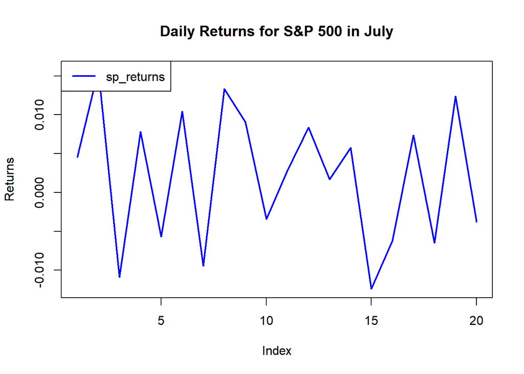

```r
plot(sp_returns, type = "l", col = "blue", lwd = 2,
     ylab = "Returns", main = "Daily Returns for S&P 500 in July")
legend(x = 'topleft', legend = 'sp_returns', lty = 1, lwd = 2, col = 'blue')
```